# Face Generation

In this project, you'll define and train a Generative Adverserial network of your own creation on a dataset of faces. Your goal is to get a generator network to generate *new* images of faces that look as realistic as possible!

The project will be broken down into a series of tasks from **defining new architectures training adversarial networks**. At the end of the notebook, you'll be able to visualize the results of your trained Generator to see how it performs; your generated samples should look like fairly realistic faces with small amounts of noise.

### Get the Data

You'll be using the [CelebFaces Attributes Dataset (CelebA)](http://mmlab.ie.cuhk.edu.hk/projects/CelebA.html) to train your adversarial networks.

This dataset has higher resolution images than datasets you have previously worked with (like MNIST or SVHN) you've been working with, and so, you should prepare to define deeper networks and train them for a longer time to get good results. It is suggested that you utilize a GPU for training.

### Pre-processed Data

Since the project's main focus is on building the GANs, we've done *some* of the pre-processing for you. Each of the CelebA images has been cropped to remove parts of the image that don't include a face, then resized down to 64x64x3 NumPy images. Some sample data is show below.

[figure not shown]

> If you are working locally, you can download this data [by clicking here](https://s3.amazonaws.com/video.udacity-data.com/topher/2018/November/5be7eb6f_processed-celeba-small/processed-celeba-small.zip)

This is a zip file that you'll need to extract in the home directory of this notebook for further loading and processing. After extracting the data, you should be left with a directory of data `processed-celeba-small/`.

```python
# run this once to unzip the file
!unzip processed-celeba-small.zip
```

```
Archive:  processed-celeba-small.zip
replace processed_celeba_small/.DS_Store? [y]es, [n]o, [A]ll, [N]one, [r]ename:
```

```python
from glob import glob
from typing import Tuple, Callable, Dict
import PIL
import matplotlib.pyplot as plt
import numpy as np
import torch
from PIL import Image
from torch.utils.data import DataLoader, Dataset
from torchvision.transforms import Compose, ToTensor, Resize, Normalize
import torchvision
import tests
```

```python
data_dir = 'processed_celeba_small/celeba/'
```

## Data pipeline

The [CelebA](http://mmlab.ie.cuhk.edu.hk/projects/CelebA.html) dataset contains over 200,000 celebrity images with annotations. Since you're going to be generating faces, you won't need the annotations, you'll only need the images. Note that these are color images with 3 color channels (RGB)#RGB_Images) each.

### Pre-process and Load the Data

Since the project's main focus is on building the GANs, we've done *some* of the pre-processing for you. Each of the CelebA images has been cropped to remove parts of the image that don't include a face, then resized down to 64x64x3 NumPy images. This *pre-processed* dataset is a smaller subset of the very large CelebA dataset and contains roughly 30,000 images.

Your first task consists in building the dataloader. To do so, you need to do the following:

- implement the get_transforms function
- create a custom Dataset class that reads the CelebA data

### Exercise: implement the get_transforms function

The `get_transforms` function should output a [`torchvision.transforms.Compose`](https://pytorch.org/vision/stable/generated/torchvision.transforms.Compose.html#torchvision.transforms.Compose) of different transformations. You have two constraints:

- the function takes a tuple of size as input and should **resize the images** to the input size
- the output images should have values **ranging from -1 to 1**

```python
def get_transforms(size):
    """ Transforms to apply to the image."""
    # TODO: edit this function by appening transforms to the below list
    transforms = [Resize(size),ToTensor()]



    return Compose(transforms)
```

### Exercise: implement the DatasetDirectory class

The `DatasetDirectory` class is a torch Dataset that reads from the above data directory. The `__getitem__` method should output a transformed tensor and the `__len__` method should output the number of files in our dataset. You can look at [this custom dataset](https://pytorch.org/tutorials/beginner/basics/data_tutorial.html#creating-a-custom-dataset-for-your-files) for ideas.

```python
import os

class DatasetDirectory(Dataset):
    def __init__(self, directory: str, transforms: Callable = None, extension: str = '.jpg'):
        self.directory=directory
        self.extension=extension
        self.transforms=transforms
    def __len__(self) -> int:
        count=0
        for files in os.listdir(self.directory):

            if files.endswith(self.extension):
                count+=1
        return count


    def __getitem__(self, index: int) -> torch.Tensor:
        """ load an image and apply transformation """
        filenameslist=[]
        for files in os.listdir(self.directory):
            if files.endswith(self.extension):
                filenameslist.append(files)


        #dataset = torch.utils.data.ImageFolder(directory, transform=self.transforms)
        #dataloader = torch.utils.data.DataLoader(dataset, batch_size=32, shuffle=True)
        name_to_read=self.directory+filenameslist[index]
        #print(name_to_read)
        image=PIL.Image.open(name_to_read)
        tensor_image = torchvision.transforms.functional.to_tensor(image)
# The image can be converted to tensor using
        tensor_image=2*tensor_image-1
        #image=self.transform(image)
        #print(min(tensor_image.flatten()))
        #print(tensor_image)
        #print(tensor_image.shape)
        #[3,64,64]
        #tensor_flatten=tensor_image.flatten()
        #original=torch.reshape(tensor_flatten,(3,64,64))
        #print(original)



        return tensor_image
```

```python
"""
DO NOT MODIFY ANYTHING IN THIS CELL
"""
# run this cell to verify your dataset implementation
dataset = DatasetDirectory(data_dir, get_transforms((64, 64)))
tests.check_dataset_outputs(dataset)
```

```
Congrats, your dataset implementation passed all the tests
```

```python
print(torch.__version__)
print(torchvision.__version__)
import os
os.getcwd()
```

```
1.11.0+cu102
0.10.0+cu102
```

```
'/home/workspace'
```

The functions below will help you visualize images from the dataset.

[figure not shown]

```python
"""
DO NOT MODIFY ANYTHING IN THIS CELL
"""

def denormalize(images):
    """Transform images from [-1.0, 1.0] to [0, 255] and cast them to uint8."""
    return ((images + 1.) / 2. * 255).astype(np.uint8)

# plot the images in the batch, along with the corresponding labels
fig = plt.figure(figsize=(20, 4))
plot_size=20
for idx in np.arange(plot_size):
    ax = fig.add_subplot(2, int(plot_size/2), idx+1, xticks=[], yticks=[])
    img = dataset[idx].numpy()
    img = np.transpose(img, (1, 2, 0))
    img = denormalize(img)
    ax.imshow(img)
```

## Model implementation

As you know, a GAN is comprised of two adversarial networks, a discriminator and a generator. Now that we have a working data pipeline, we need to implement the discriminator and the generator.

Feel free to implement any additional class or function.

### Exercise: Create the discriminator

The discriminator's job is to score real and fake images. You have two constraints here:

- the discriminator takes as input a **batch of 64x64x3 images**
- the output should be a single value (=score)

Feel free to get inspiration from the different architectures we talked about in the course, such as DCGAN, WGAN-GP or DRAGAN.

#### Some tips

- To scale down from the input image, you can either use `Conv2d` layers with the correct hyperparameters or Pooling layers.
- If you plan on using gradient penalty, do not use Batch Normalization layers in the discriminator.

```python
from torch.nn import Module,Sequential, Flatten, Linear, LeakyReLU
```

```python
input_dim=64*64*3
output_dim=10

class Discriminator(Module):
    def __init__(self,input_dim=64*64*3,hidden_dim=128):
        super(Discriminator, self).__init__()

        self.model=Sequential(torch.nn.Flatten(),Linear(input_dim,output_dim),
                           LeakyReLU(), Linear(output_dim,1))

    def forward(self, x: torch.Tensor):
        x=self.model(x)
        x=torch.reshape(x,[-1,1,1,1])
        return x
```

```python
class Discriminator(Module):
    def __init__(self,input_dim=64*64*3,hidden_dim=128):
        super(Discriminator, self).__init__()
        self.fc1=Linear(input_dim,hidden_dim)
        self.fc2=Linear(hidden_dim,hidden_dim//2)
        self.fc3=Linear(hidden_dim//2,hidden_dim//4)
        self.fc4=Linear(hidden_dim//4,1)
        self.dropout = torch.nn.Dropout(0.3)
        self.activation = torch.nn.LeakyReLU(0.2)

    def forward(self, x: torch.Tensor):
        x=x.view(-1,64*64*3)
        x=self.fc1(x)
        x=self.activation(x)
        x=self.dropout(x)

        x=self.fc2(x)
        x=self.activation(x)
        x=self.dropout(x)

        x=self.fc3(x)
        x=self.activation(x)
        x=self.dropout(x)

        x=self.fc4(x)

        x=torch.reshape(x,[-1,1,1,1])
        return x
```

```python
"""
DO NOT MODIFY ANYTHING IN THIS CELL
"""
# run this cell to check your discriminator implementation
discriminator = Discriminator()
tests.check_discriminator(discriminator)
```

```
Congrats, your discriminator implementation passed all the tests
```

### Exercise: create the generator

- the generator takes as input a vector of dimension `[batch_size, latent_dimension, 1, 1]`
- the generator must outputs **64x64x3 images**

Feel free to get inspiration from the different architectures we talked about in the course, such as DCGAN, WGAN-GP or DRAGAN.

#### Some tips:

- to scale up from the latent vector input, you can use `ConvTranspose2d` layers
- as often with Gan, **Batch Normalization** helps with training

```python
hidden_dim=100
class Generator(Module):
    def __init__(self, latent_dim: int):
        super(Generator, self).__init__()
        self.model=Sequential(Linear(latent_dim,hidden_dim),LeakyReLU(0.2)
        ,Linear(hidden_dim,input_dim))

    def forward(self, x: torch.Tensor) -> torch.Tensor:

        x=torch.reshape(x,(-1,latent_dim))
        x=self.model(x)
        original=torch.reshape(x,(-1,3,64,64))
        return original
```

```python
class Generator(Module):
    def __init__(self, latent_dim: int, hidden_dim=32, output_size=3*64*64):
        super(Generator, self).__init__()
        # define hidden linear layers
        self.fc1 = Linear(latent_dim, hidden_dim)
        self.fc2 = Linear(hidden_dim, hidden_dim*2)
        self.fc3 = Linear(hidden_dim*2, hidden_dim*4)

        # final fully-connected layer
        self.fc4 = Linear(hidden_dim*4, output_size)

        # define the activation
        self.activation = torch.nn.LeakyReLU(0.2)
        self.final_activation = torch.nn.Tanh()

    def forward(self, x: torch.Tensor) -> torch.Tensor:
        x=torch.reshape(x,(-1,latent_dim))
        x = self.fc1(x)
        x = self.activation(x)

        x = self.fc2(x)
        x = self.activation(x)

        x = self.fc3(x)
        x = self.activation(x)

        x = self.fc4(x)
        x = self.final_activation(x)
        x= torch.reshape(x,(-1,3,64,64))
        return x
```

```python
"""
DO NOT MODIFY ANYTHING IN THIS CELL
"""
# run this cell to verify your generator implementation
latent_dim = 128
generator = Generator(latent_dim)
tests.check_generator(generator, latent_dim)
```

```
Congrats, your generator implementation passed all the tests
```

## Optimizer

In the following section, we create the optimizers for the generator and discriminator. You may want to experiment with different optimizers, learning rates and other hyperparameters as they tend to impact the output quality.

### Exercise: implement the optimizers

```python
import torch.optim as optim


def create_optimizers(generator: Module, discriminator: Module,lr=0.001):
    """ This function should return the optimizers of the generator and the discriminator """
    # TODO: implement the generator and discriminator optimizers
    g_optimizer = optim.SGD(generator.parameters(), lr)

    d_optimizer =optim.SGD(discriminator.parameters(), lr)
    return g_optimizer, d_optimizer
```

## Losses implementation

In this section, we are going to implement the loss function for the generator and the discriminator. You can and should experiment with different loss function.

Some tips:

- You can choose the commonly used the binary cross entropy loss or select other losses we have discovered in the course, such as the Wasserstein distance.
- You may want to implement a gradient penalty function as discussed in the course. It is not required and the code will work whether you implement it or not.

### Exercise: implement the generator loss

The generator's goal is to get the discriminator to think its generated images (= "fake" images) are real.

```python
def generator_loss(fake_logits):
    """ Generator loss, takes the fake scores as inputs. """
    loss = -torch.sum(torch.log(torch.exp(fake_logits)+1))
    return loss
```

### Exercise: implement the discriminator loss

We want the discriminator to give high scores to real images and low scores to fake ones and the discriminator loss should reflect that.

```python
def discriminator_loss(real_logits, fake_logits):
    """ Discriminator loss, takes the fake and real logits as inputs. """
    loss= torch.sum(torch.log(torch.exp(fake_logits)+1))+torch.sum(-real_logits)+torch.sum(torch.log(torch.exp(real_logits)+1))
    #loss=torch.sum(-real_logits)+torch.sum(torch.log(torch.exp(real_logits)+1))
    return loss
```

### Exercise (Optional): Implement the gradient Penalty

In the course, we discussed the importance of gradient penalty in training certain types of Gans. Implementing this function is not required and depends on some of the design decision you made (discriminator architecture, loss functions).

```python
def gradient_penalty(discriminator, real_samples, fake_samples):
    """ This function enforces """
    gp = 0
    # TODO (Optional): implement the gradient penalty
    return gp
```

## Training

- You should train the discriminator by alternating on real and fake images
- Then the generator, which tries to trick the discriminator and should have an opposing loss function

### Exercise: implement the generator step and the discriminator step functions

Each function should do the following:

- calculate the loss
- backpropagate the gradient
- perform one optimizer step

```python
def generator_step(batch_size: int, latent_dim: int):
    """ One training step of the generator. """
    # TODO: implement the generator step (foward pass, loss calculation and backward pass)

    g_optimizer.zero_grad()

    fake_images=generator(torch.normal(torch.zeros(batch_size,latent_dim),torch.ones(batch_size,latent_dim)).to(device))

    fake_logits=discriminator(fake_images.detach())



    g_loss=generator_loss(fake_logits)
    if not torch.isnan(g_loss):
        g_loss.backward(retain_graph=True)
        g_optimizer.step()


    return {'loss': g_loss,"fake_logits":fake_logits}
    #return g_loss


def discriminator_step(batch_size: int, latent_dim: int, real_images: torch.Tensor,fake_logits):
    """ One training step of the discriminator. """
    # TODO: implement the discriminator step (foward pass, loss calculation and backward pass)
    d_optimizer.zero_grad()
    real_logits=discriminator(real_images)
    d_loss=discriminator_loss(real_logits,fake_logits)
    if not torch.isnan(d_loss):
        d_loss.backward()
        d_optimizer.step()

    return {'loss': d_loss}
```

### Main training loop

You don't have to implement anything here but you can experiment with different hyperparameters.

```python
from datetime import datetime
```

```python
# you can experiment with different dimensions of latent spaces
latent_dim = 128

# update to cpu if you do not have access to a gpu
device = 'cuda'

# number of epochs to train your model
n_epochs = 1

# number of images in each batch
batch_size = 64

#lr=0.001
```

```python
"""
DO NOT MODIFY ANYTHING IN THIS CELL
"""
print_every = 1

# Create optimizers for the discriminator D and generator G
generator = Generator(latent_dim).to(device)
discriminator = Discriminator().to(device)

lr=0.00001
g_optimizer, d_optimizer = create_optimizers(generator, discriminator,lr=0.0001)

dataloader = DataLoader(dataset,
                        batch_size=64,
                        shuffle=True,
                        num_workers=4,
                        drop_last=True,
                        pin_memory=False)
```

```python
"""
DO NOT MODIFY ANYTHING IN THIS CELL
"""

def display(fixed_latent_vector: torch.Tensor):
    """ helper function to display images during training """
    fig = plt.figure(figsize=(14, 4))
    plot_size = 16
    for idx in np.arange(plot_size):
        ax = fig.add_subplot(2, int(plot_size/2), idx+1, xticks=[], yticks=[])
        img = fixed_latent_vector[idx, ...].detach().cpu().numpy()
        img = np.transpose(img, (1, 2, 0))
        img = denormalize(img)
        ax.imshow(img)
    plt.show()
```

### Exercise: implement the training strategy

You should experiment with different training strategies. For example:

- train the generator more often than the discriminator.
- added noise to the input image
- use label smoothing

Implement with your training strategy below.

```
2023-01-28 22:06:53 | Epoch [1/1] | Batch 0/509 | d_loss: 89.5347 | g_loss: -46.5938
2023-01-28 22:06:53 | Epoch [1/1] | Batch 1/509 | d_loss: 88.9686 | g_loss: -46.5569
2023-01-28 22:06:53 | Epoch [1/1] | Batch 2/509 | d_loss: 88.5232 | g_loss: -46.4383
2023-01-28 22:06:53 | Epoch [1/1] | Batch 3/509 | d_loss: 88.2065 | g_loss: -46.3452
2023-01-28 22:06:57 | Epoch [1/1] | Batch 4/509 | d_loss: 88.3429 | g_loss: -46.5914
2023-01-28 22:06:57 | Epoch [1/1] | Batch 5/509 | d_loss: 87.9193 | g_loss: -46.2719
2023-01-28 22:06:57 | Epoch [1/1] | Batch 6/509 | d_loss: 87.9299 | g_loss: -46.2482
2023-01-28 22:06:58 | Epoch [1/1] | Batch 7/509 | d_loss: 87.6235 | g_loss: -46.3169
2023-01-28 22:07:02 | Epoch [1/1] | Batch 8/509 | d_loss: 87.4770 | g_loss: -46.1538
2023-01-28 22:07:02 | Epoch [1/1] | Batch 9/509 | d_loss: 87.4017 | g_loss: -46.1995
2023-01-28 22:07:02 | Epoch [1/1] | Batch 10/509 | d_loss: 87.5223 | g_loss: -46.2313
2023-01-28 22:07:02 | Epoch [1/1] | Batch 11/509 | d_loss: 87.2331 | g_loss: -46.3132
2023-01-28 22:07:07 | Epoch [1/1] | Batch 12/509 | d_loss: 86.6980 | g_loss: -46.1695
2023-01-28 22:07:07 | Epoch [1/1] | Batch 13/509 | d_loss: 86.3631 | g_loss: -45.9449
2023-01-28 22:07:07 | Epoch [1/1] | Batch 14/509 | d_loss: 86.0029 | g_loss: -45.9584
2023-01-28 22:07:07 | Epoch [1/1] | Batch 15/509 | d_loss: 85.9917 | g_loss: -45.9591
2023-01-28 22:07:10 | Epoch [1/1] | Batch 16/509 | d_loss: 85.8543 | g_loss: -45.8238
2023-01-28 22:07:11 | Epoch [1/1] | Batch 17/509 | d_loss: 85.9366 | g_loss: -46.0045
2023-01-28 22:07:12 | Epoch [1/1] | Batch 18/509 | d_loss: 85.8774 | g_loss: -45.9556
2023-01-28 22:07:12 | Epoch [1/1] | Batch 19/509 | d_loss: 84.6165 | g_loss: -45.7401
2023-01-28 22:07:15 | Epoch [1/1] | Batch 20/509 | d_loss: 84.6727 | g_loss: -45.9663
2023-01-28 22:07:16 | Epoch [1/1] | Batch 21/509 | d_loss: 84.6640 | g_loss: -45.8054
2023-01-28 22:07:16 | Epoch [1/1] | Batch 22/509 | d_loss: 84.6636 | g_loss: -45.7413
2023-01-28 22:07:16 | Epoch [1/1] | Batch 23/509 | d_loss: 84.5790 | g_loss: -45.5824
2023-01-28 22:07:20 | Epoch [1/1] | Batch 24/509 | d_loss: 84.0959 | g_loss: -45.5458
2023-01-28 22:07:20 | Epoch [1/1] | Batch 25/509 | d_loss: 84.1620 | g_loss: -45.7707
2023-01-28 22:07:20 | Epoch [1/1] | Batch 26/509 | d_loss: 83.7915 | g_loss: -45.6304
2023-01-28 22:07:20 | Epoch [1/1] | Batch 27/509 | d_loss: 83.8551 | g_loss: -45.5600
2023-01-28 22:07:24 | Epoch [1/1] | Batch 28/509 | d_loss: 83.3806 | g_loss: -45.5805
2023-01-28 22:07:24 | Epoch [1/1] | Batch 29/509 | d_loss: 82.9358 | g_loss: -45.4680
2023-01-28 22:07:24 | Epoch [1/1] | Batch 30/509 | d_loss: 82.6342 | g_loss: -45.4531
2023-01-28 22:07:24 | Epoch [1/1] | Batch 31/509 | d_loss: 82.5791 | g_loss: -45.2775
2023-01-28 22:07:29 | Epoch [1/1] | Batch 32/509 | d_loss: 81.5538 | g_loss: -45.6047
2023-01-28 22:07:29 | Epoch [1/1] | Batch 33/509 | d_loss: 81.9283 | g_loss: -45.3760
2023-01-28 22:07:29 | Epoch [1/1] | Batch 34/509 | d_loss: 81.5308 | g_loss: -45.3069
2023-01-28 22:07:30 | Epoch [1/1] | Batch 35/509 | d_loss: 81.9464 | g_loss: -45.2501
2023-01-28 22:07:34 | Epoch [1/1] | Batch 36/509 | d_loss: 80.7235 | g_loss: -45.4089
2023-01-28 22:07:34 | Epoch [1/1] | Batch 37/509 | d_loss: 80.6335 | g_loss: -45.2075
2023-01-28 22:07:34 | Epoch [1/1] | Batch 38/509 | d_loss: 79.1274 | g_loss: -45.1918
2023-01-28 22:07:34 | Epoch [1/1] | Batch 39/509 | d_loss: 79.6245 | g_loss: -45.3464
```

[output cut: 454 more lines]

```
2023-01-28 22:15:45 | Epoch [1/1] | Batch 494/509 | d_loss: 1.5665 | g_loss: -1.2048
2023-01-28 22:15:45 | Epoch [1/1] | Batch 495/509 | d_loss: 1.0058 | g_loss: -0.8819
2023-01-28 22:15:46 | Epoch [1/1] | Batch 496/509 | d_loss: 3.1587 | g_loss: -1.6471
2023-01-28 22:15:46 | Epoch [1/1] | Batch 497/509 | d_loss: 1.7836 | g_loss: -1.2790
2023-01-28 22:15:49 | Epoch [1/1] | Batch 498/509 | d_loss: 2.1116 | g_loss: -1.5758
2023-01-28 22:15:49 | Epoch [1/1] | Batch 499/509 | d_loss: 1.2511 | g_loss: -1.0803
2023-01-28 22:15:50 | Epoch [1/1] | Batch 500/509 | d_loss: 4.2690 | g_loss: -1.5652
2023-01-28 22:15:50 | Epoch [1/1] | Batch 501/509 | d_loss: 2.1481 | g_loss: -1.2032
2023-01-28 22:15:53 | Epoch [1/1] | Batch 502/509 | d_loss: 3.0195 | g_loss: -1.6669
2023-01-28 22:15:53 | Epoch [1/1] | Batch 503/509 | d_loss: 1.8356 | g_loss: -1.3322
2023-01-28 22:15:53 | Epoch [1/1] | Batch 504/509 | d_loss: 2.9282 | g_loss: -1.1690
2023-01-28 22:15:53 | Epoch [1/1] | Batch 505/509 | d_loss: 1.8102 | g_loss: -0.9834
2023-01-28 22:15:55 | Epoch [1/1] | Batch 506/509 | d_loss: 1.6845 | g_loss: -1.4079
2023-01-28 22:15:55 | Epoch [1/1] | Batch 507/509 | d_loss: 3.0020 | g_loss: -1.2658
2023-01-28 22:15:55 | Epoch [1/1] | Batch 508/509 | d_loss: 1.4674 | g_loss: -1.1800
```

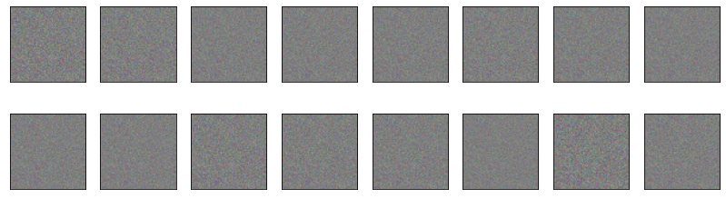

```python
fixed_latent_vector = torch.randn(16, latent_dim, 1, 1).float().cuda()

losses = []
for epoch in range(n_epochs):
    for batch_i, real_images in enumerate(dataloader):
        real_images = real_images.to(device)

        ####################################
        g_loss=generator_step(batch_size,latent_dim)
        fake_logits=g_loss["fake_logits"]
        d_loss=discriminator_step(batch_size,latent_dim,real_images,fake_logits)

        ####################################

        if batch_i % print_every == 0:
            # append discriminator loss and generator loss
            d = d_loss['loss'].item()
            g = g_loss['loss'].item()
            losses.append((d, g))
            # print discriminator and generator loss
            time = str(datetime.now()).split('.')[0]
            print(f'{time} | Epoch [{epoch+1}/{n_epochs}] | Batch {batch_i}/{len(dataloader)} | d_loss: {d:.4f} | g_loss: {g:.4f}')

    # display images during training
    generator.eval()
    generated_images = generator(fixed_latent_vector)
    display(generated_images)
    generator.train()
```

### Training losses

Plot the training losses for the generator and discriminator.

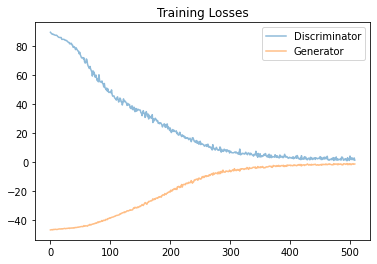

```python
"""
DO NOT MODIFY ANYTHING IN THIS CELL
"""
fig, ax = plt.subplots()
losses = np.array(losses)
plt.plot(losses.T[0], label='Discriminator', alpha=0.5)
plt.plot(losses.T[1], label='Generator', alpha=0.5)
plt.title("Training Losses")
plt.legend()
```

### Question: What do you notice about your generated samples and how might you improve this model?

When you answer this question, consider the following factors:

- The dataset is biased; it is made of "celebrity" faces that are mostly white
- Model size; larger models have the opportunity to learn more features in a data feature space
- Optimization strategy; optimizers and number of epochs affect your final result
- Loss functions

### Submitting This Project

When submitting this project, make sure to run all the cells before saving the notebook. Save the notebook file as "dlnd_face_generation.ipynb".

Submit the notebook using the *SUBMIT* button in the bottom right corner of the Project Workspace.